# Zomato_Case_Study

## -->The dataset is highly skewed toward the cities included in Delhi-NCR. So, we will summarise all the other cities in Rest of India while those in New Delhi, Ghaziabad, Noida, Gurgaon, Faridabad to Delhi-NCR. Doing this would make our analysis turn toward Delhi-NCR v Rest of India.

## 1.Plot the bar graph of number of restaurants present in Delhi NCR vs Rest of India.

```
The no of Restaurants under Delhi-NCR are 7947
The no of Restaurants under other cities are 705
```

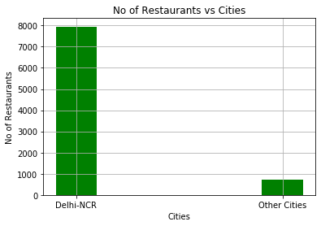

```python
import numpy as np
import pandas as pd
import matplotlib.pyplot as plt
count1=0
count2=0
data = pd.read_csv('Datasets/zomato.csv',encoding='latin-1')
df1=data.copy()
df1['Country Code'].dropna(inplace=True)
l=[]
data_india= df1[df1['Country Code']==1]
for i in data_india['City']:
    if(i=='New Delhi'or i=='Ghaziabad' or i=='Noida' or i=='Gurgaon' or i=='Faridabad'):
            count1+=1
    else:
            count2+=1

print("The no of Restaurants under Delhi-NCR are",count1)
print("The no of Restaurants under other cities are",count2)
plt.bar(['Delhi-NCR','Other Cities'], [count1,count2],width=0.2,color="green")
plt.xlabel("Cities")
plt.ylabel("No of Restaurants")
plt.title("No of Restaurants vs Cities")
plt.grid()
plt.show()
```

## 2. Find the cuisines which are not present in restaurant of Delhi NCR but present in rest of India.Check using Zomato API whether this cuisines are actually not served in restaurants of Delhi-NCR or just it due to incomplete dataset.

```python
import numpy as np
import pandas as pd
import matplotlib.pyplot as plt
data = pd.read_csv('Datasets/zomato.csv',encoding='latin-1')
df1=data.copy()
df1['Country Code'].dropna(inplace=True)
df1['City'].dropna(inplace=True)
df1['Cuisines'].dropna(inplace=True)
data_india= df1[df1['Country Code']==1]
d_cuisines_ncr={}
d_cuisines_roi={}
delhi_ncr=data_india[(data_india['City']=='New Delhi')|(data_india['City']=='Ghaziabad') | (data_india['City']=='Noida') |(data_india['City']=='Gurgaon') | (data_india['City']=='Faridabad')]
other_cities=data_india[(data_india['City']!='New Delhi')| (data_india['City']!='Ghaziabad') | (data_india['City']!='Noida') |(data_india['City']!='Gurgaon') | (data_india['City']!='Faridabad')]
for i in delhi_ncr['Cuisines']:
    temp = i.split(',')
    for x in temp:
        d_cuisines_ncr[x.strip()] = d_cuisines_ncr.get(x.strip(), 0) + 1
for i in other_cities['Cuisines']:
    temp = i.split(',')
    for x in temp:
        d_cuisines_roi[x.strip()] = d_cuisines_roi.get(x.strip(), 0) + 1

different_cuisines = set(d_cuisines_roi) - set(d_cuisines_ncr)
print("The Following are the Cuisines which are not present in Restaurants of Delhi-NCR but present in Rest of India:")
for i in different_cuisines:
    print("->",i)
```

```
The Following are the Cuisines which are not present in Restaurants of Delhi-NCR but present in Rest of India:
-> BBQ
-> Cajun
-> Malwani
-> German
```

## 3.Find the top 10 cuisines served by maximum number of restaurants in Delhi NCR and rest of India.

```python
import numpy as np
import pandas as pd
import matplotlib.pyplot as plt
import itertools
data = pd.read_csv('Datasets/zomato.csv',encoding='latin-1')
df1=data.copy()
df1['Country Code'].dropna(inplace=True)
df1['City'].dropna(inplace=True)
df1['Cuisines'].dropna(inplace=True)
data_india= df1[df1['Country Code']==1]
d_cuisines_ncr={}
d_cuisines_roi={}
delhi_ncr=data_india[(data_india['City']=='New Delhi')|(data_india['City']=='Ghaziabad') | (data_india['City']=='Noida') |(data_india['City']=='Gurgaon') | (data_india['City']=='Faridabad')]
other_cities=data_india[(data_india['City']!='New Delhi')| (data_india['City']!='Ghaziabad') | (data_india['City']!='Noida') |(data_india['City']!='Gurgaon') | (data_india['City']!='Faridabad')]
for i in delhi_ncr['Cuisines']:
    temp = i.split(',')
    for x in temp:
        d_cuisines_ncr[x.strip()] = d_cuisines_ncr.get(x.strip(), 0) + 1
for i in other_cities['Cuisines']:
    temp = i.split(',')
    for x in temp:
        d_cuisines_roi[x.strip()] = d_cuisines_roi.get(x.strip(), 0) + 1
d_cuisines_ncr.update(d_cuisines_roi)
sorted_dict = sorted(d_cuisines_ncr.items(), key = lambda kv:(kv[1], kv[0]), reverse = True)
#print(sorted_dict)
print("The Following are the top 10 Cuisines which are  present in Restaurants of Delhi-NCR and  Rest of India:")
c=0
for i in sorted_dict:
    if c==10:
        break
    c+=1
    print("->",i[0],i[1])
```

```
The Following are the top 10 Cuisines which are  present in Restaurants of Delhi-NCR and  Rest of India:
-> North Indian 3946
-> Chinese 2690
-> Fast Food 1963
-> Mughlai 992
-> Bakery 726
-> Continental 724
-> Italian 682
-> South Indian 631
-> Cafe 627
-> Desserts 597
```

## 4.Write a short detailed analysis of how cuisine served is different from Delhi NCR to Rest of India. Plot the suitable graph to explain your inference.

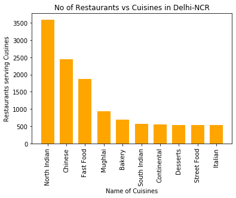

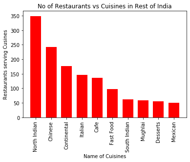

[output not shown]

```python
import numpy as np
import pandas as pd
import matplotlib.pyplot as plt
import itertools
data = pd.read_csv('Datasets/zomato.csv',encoding='latin-1')
df1=data.copy()
df1['Country Code'].dropna(inplace=True)
df1['City'].dropna(inplace=True)
df1['Cuisines'].dropna(inplace=True)
data_india= df1[df1['Country Code']==1]
d_cuisines_ncr={}
d_cuisines_roi={}
delhi_ncr=data_india[(data_india['City']=='New Delhi')|(data_india['City']=='Ghaziabad') | (data_india['City']=='Noida') |(data_india['City']=='Gurgaon') | (data_india['City']=='Faridabad')]
other_cities=data_india[(data_india['City']!='New Delhi')& (data_india['City']!='Ghaziabad') & (data_india['City']!='Noida') &(data_india['City']!='Gurgaon') & (data_india['City']!='Faridabad')]
for i in delhi_ncr['Cuisines']:
    temp = i.split(',')
    for x in temp:
        d_cuisines_ncr[x.strip()] = d_cuisines_ncr.get(x.strip(), 0) + 1
for i in other_cities['Cuisines']:
    temp = i.split(',')
    for x in temp:
        d_cuisines_roi[x.strip()] = d_cuisines_roi.get(x.strip(), 0) + 1
sorted_d_cuisines_ncr = sorted(d_cuisines_ncr.items(), key = lambda kv:(kv[1], kv[0]), reverse = True)
sorted_d_cuisines_roi = sorted(d_cuisines_roi.items(), key = lambda kv:(kv[1], kv[0]), reverse = True)
c=0
c1=0
name_delhi_ncr=[]
num_delhi_ncr=[]
name_roi=[]
num_roi=[]
for i in sorted_d_cuisines_ncr:
    if c==10:
        break
    c+=1
    name_delhi_ncr.append(i[0])
    num_delhi_ncr.append(i[1])
plt.bar(name_delhi_ncr,num_delhi_ncr,width=0.7,color="orange")
plt.xticks(rotation=90)
plt.xlabel("Name of Cuisines")
plt.ylabel("Restaurants serving Cusines")
plt.title("No of Restaurants vs Cuisines in Delhi-NCR")
plt.show()


for i in sorted_d_cuisines_roi:
    if c1==10:
        break
    c1+=1
    name_roi.append(i[0])
    num_roi.append(i[1])
plt.bar(name_roi,num_roi,width=0.7,color="red")
plt.xticks(rotation=90)
plt.xlabel("Name of Cuisines")
plt.ylabel("Restaurants serving Cusines")
plt.title("No of Restaurants vs Cuisines in Rest of India")
plt.show()
print("From both the graphs we can conclude that most of the North Indian Cuisines is served in Delhi-NCR with the no of restaurants 3547 whereas in rest of India it is 349 which is very less as compared to delhi-NCR. Also the count of Restaurants serving Chinese Cuisine in More")



#TOP 10 CUISINE SERVED IN MAXIMUM NUMBER OF RESTAURANTS IN REST OF INDIA:
#------------------------------------------------------------------------
#CUISINE		| NUMBER OF RESTAURANTS
#North Indian    |        349
#Chinese         |        242
#Continental     |        177
#Italian         |        14
#Cafe            |        136
#Fast Food       |         97
#South Indian    |         62
#Mughlai         |         59
#Desserts        |         55
#Mexican         |         50


#TOP 10 CUISINE SERVED IN MAXIMUM NUMBER OF RESTAURANTS IN DELHI-NCR:
#------------------------------------------------------------------------
#CUISINE		| NUMBER OF RESTAURANTS
#North Indian    |       3597
#Chinese         |       2448
#Fast Food       |       1866
#Mughlai         |        933
#Bakery          |        697
#South Indian    |        569
#Continental     |        547
#Desserts        |        542
#treet Food     |        538
#talian         |        535
```

## -->User Rating of a restaurant plays a crucial role in selecting a restaurant or ordering the food from the restaurant.

## 1.Write a short detail analysis of how the rating is affected by restaurant due following features: Plot a suitable graph to explain your inference.

## i) How does aggregate user rating varies with number of votes

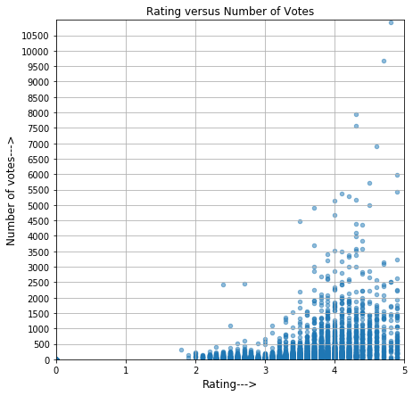

[output not shown]

```python
import matplotlib.pyplot as plt
import numpy as np
import pandas as pd
data=pd.read_csv('Datasets/zomato.csv', encoding='ISO-8859-1')
df=data.copy()
#i didn't do anything much. just plotted the graph
plt.figure(figsize=(7, 7))
plt.scatter(df['Aggregate rating'], df['Votes'], s=20, alpha=0.5)
plt.yticks(np.arange(0, 11000, 500))
plt.axis([0, 5, 0, 11000])
plt.xlabel('Rating--->', size=12)
plt.ylabel('Number of votes--->', size=12)
plt.title('Rating versus Number of Votes')
plt.grid()
plt.show()
print("Clearly as the number of votes increases the chances of getting higher ratings also increases. It is clear from the graph that any restaurants with more than 5000 votes get ratings between 4 and 5. when the voes are less than 2000, there is a diversity of ratings, which varies from 2 to 5. so for a restaurant to have a probability of getting higher aggregate rating, it should have more than 5000 votes. Also there are many restaurants having votes between between 1000 and 2000 with very good ratings, that is between 4 and 5.")
```

## ii)How does aggregate user rating varies with number of cuisines served

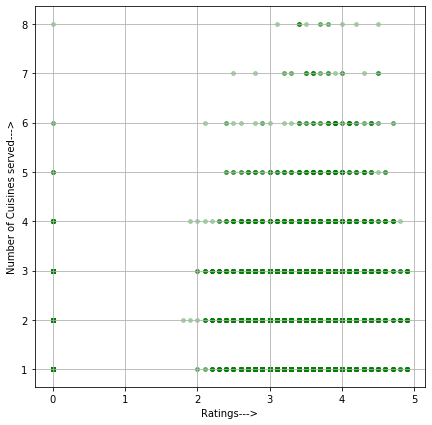

[output not shown]

```python
df=df.loc[df.Cuisines.notnull()]
cuisines=[len(i.split(',')) for i in df.Cuisines]
rating=[i for i in df['Aggregate rating']]
plt.figure(figsize=(7, 7))
plt.scatter(rating, cuisines, c='green', s=15, alpha=0.3)
plt.xlabel('Ratings--->')
plt.ylabel('Number of Cuisines served--->')
plt.grid()
plt.show()
dic=dict()
for i in cuisines:
    if i in dic.keys():
        dic[i]+=1
    else:
        dic[i]=1
for i in dic.keys():
    print("number of cuisines served= ", i, ", number of restaurants serving given number of cuisines= ", dic[i])
print("\nFrom the graph itself, it is clear that when the number of cuisines provided increases from 3 to 8, generally the rating seems to converge between 3 and 4. restaurants providing more number of cuisines are not much likely to get higher ratings, specially when the number of cuisines provided exceeds 6. while if the restaurants provide less number of cuisines, for example 1 or 2 cuisines, they are more likely to get higher ratings. Infact many restaurants in india are providing 2 cuisines. there is a very less number of restaurants providing 8 cuisines. it seems like when a restaurant provides too many cuisines, its focus on the quality of food offered diverges. while restaurants providing less cuisines focus on the quality of food to get good aggregate ratings.")
```

## iii)How does aggregate user rating varies with average cost of the restaurant

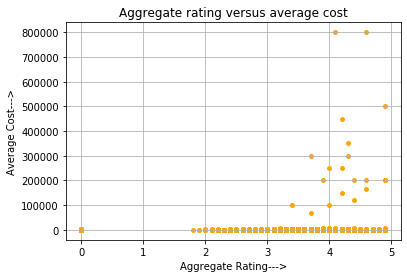

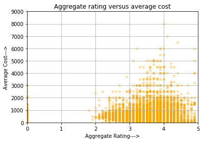

[output not shown]

```python
df=data.copy()
plt.figure(figsize=(7, 7))


plt.subplots(0, 1)
plt.scatter(df['Aggregate rating'], df['Average Cost for two'], s=15, c='orange')
plt.grid()
plt.xlabel('Aggregate Rating--->')
plt.ylabel('Average Cost--->')
plt.title('Aggregate rating versus average cost')
plt.show()


plt.subplots(0, 2)
plt.scatter(df['Aggregate rating'], df['Average Cost for two'], s=15, c='orange', alpha=0.3)
plt.grid()
plt.axis([0, 5, 0, 9000])
plt.xlabel('Aggregate Rating--->')
plt.ylabel('Average Cost--->')
plt.title('Aggregate rating versus average cost')
plt.show()
print("In the first subplot we can see that when the average cost goes higher than 1 lakh the rating is generally between 4 and 5, and ofcourse it sholud be like that only, because when the average cost is too high itself, the food quality should also be at its peak.This subplot dosen't give us much details about the variation of rating with the average cost. The second subplot is made by narrowing the range of average cost for two.As the average cost goes in between 2000, to 6000, it seems like the food is not worth the money because in that case the average rating is generally between 3 and 4. whereas when the average cost is between 1000 to 2000, the rating varies from 3 to 4.5 mostly. But for the higher price ranges the rating is between 3 and 4.")
```

## iv)How does the aggregate user rating varies with restaurants serving some specific cuisines.

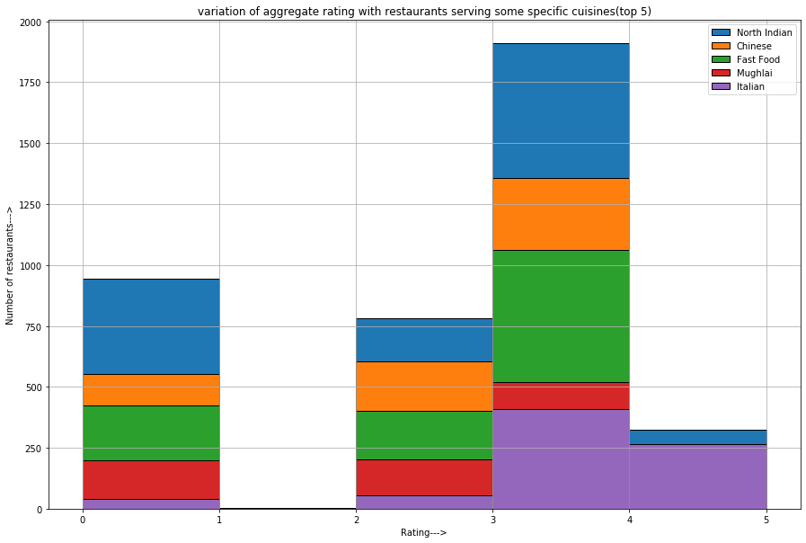

[output not shown]

```python
df=data.copy()
df=df.loc[df.Cuisines.notnull()]
cuisines=[]
for i in df.Cuisines:
    for j in i.split(','):
        cuisines.append(j)
dic=dict()
for i in cuisines:
    if i.strip() in dic.keys():
        dic[i.strip()]+=1
    else:
        dic[i.strip()]=1
cus=np.array([i for i in dic.keys()])
freq=np.array([i for i in dic.values()])

cus=cus[np.argsort(freq)][::-1]
freq=freq[np.argsort(freq)][::-1]
popular_cuisines=cus[:5]
plt.figure(figsize=(15, 10))
for i in popular_cuisines:
    rating=[]
    for j, k in zip(df.Cuisines, df['Aggregate rating']):
        if i in j:
            rating.append(k)
    plt.hist(rating, edgecolor='black', bins=[0, 1, 2, 3, 4, 5])
    plt.xlabel('Rating--->')
    plt.ylabel('Number of restaurants--->')
    plt.title('variation of aggregate rating with restaurants serving some specific cuisines(top 5)')
plt.grid()
plt.legend(labels=popular_cuisines)
plt.show()
print("From the above histrogram plot, it is clear that North indian cuisinie is the best rated among all the cuisinies in all the aggregate ranges. After it comes the chinese cuisinie, it is rated between 3 to 4 maximum number of times. Then we have Fast Food, which has been rated between 3 to 4 stars maximum number of times.after these comes mughlai and italian cuisines.it seems like people like the italian cuisinie very much because it has a considerable rating between 3 to 4 and 4 to 5 also.")
```

# 2.Find the weighted restaurant rating of each locality and find out the top 10 localities with more weighted restaurant rating?

# i) Weighted Restaurant Rating=Σ (number of votes * rating) / Σ (number of votes) .

```python
df=data.copy()
np_rating=np.array([i for i in df['Aggregate rating']])
np_votes=np.array([i for i in df['Votes']])
np_locality=np.array([i for i in df['Locality']])
dic=dict()
for i in set(np_locality):
    if sum(np_votes[np.argwhere(np_locality==i)])[0]!=0:
        dic[i]=sum((np_votes*np_rating)[np.argwhere(np_locality==i)])[0]/sum(np_votes[np.argwhere(np_locality==i)])[0]
        #here i have just applied the complete formula to calculate Weighted restaurant rating  in each locality
        #here i is the locality name and this leanthy term is the formula for calculating  WRR.
        #sum((np_votes*np_rating)[np.argwhere(np_locality==i)])[0] here [0] at the last is used because the result i will get from sum((np_votes*np_rating)[np.argwhere(np_locality==i)]) is an array with one number. thats why i have indexed it to get that number.
        #same is the case with sum(np_votes[np.argwhere(np_locality==i)])[0]
np_local=np.array([i for i in dic.keys()])#numpy array of locality
np_wrr=np.array([i for i in dic.values()])#weighted restaurant rating
np_local=np_local[np.argsort(np_wrr)][::-1]#arranged in descending order
np_wrr=np.sort(np_wrr)[::-1]#arranged in desceding order
for i in range(len(np_wrr)):
    print(np_local[i], "----->", np_wrr[i])
```

```
Beak Street, Soho -----> 4.9
Caddebostan -----> 4.9
DIFC -----> 4.9
Fort Street -----> 4.9
The Milk District -----> 4.9
Aminabad -----> 4.9
Cengkareng -----> 4.9
Setor De Clubes Esportivos Sul -----> 4.9
Old Dutch Hospital, Fort -----> 4.9
Marshalltown -----> 4.9
Deira City Centre Area -----> 4.9
Gíçvea -----> 4.9
Venetian Village, Al Maqtaa -----> 4.9
Nassima Royal Hotel, Trade Centre Area -----> 4.9
Hotel Clarks Amer, Malviya Nagar -----> 4.9
Kenwood -----> 4.9
Windermere -----> 4.9
Sofitel Philippine Plaza Manila, Pasay City -----> 4.9
City and Suburban -----> 4.9
Taman Impian Jaya Ancol, Ancol -----> 4.9
Pondok Aren -----> 4.9
Barwa Towers, Al Sadd -----> 4.9
Bishopsgate, City Of London -----> 4.9
Penjaringan -----> 4.9
Paia -----> 4.9
New Tampa -----> 4.9
Bebek -----> 4.9
Lexington Street, Soho -----> 4.9
West Park -----> 4.9
Friends Colony -----> 4.886916367367881
Powai -----> 4.841868613138686
Kirlampudi Layout -----> 4.820161290322581
Muwailih Commercial -----> 4.8
UP Town Center, Diliman, Quezon City -----> 4.8
Century City Mall, Poblacion, Makati City -----> 4.8
Centro -----> 4.8
Sanford -----> 4.8
Galeria River, Copacabana -----> 4.8
Express Avenue Mall,  Royapettah -----> 4.8
Hotel Unique, Jardim Paulista -----> 4.8
```

[output cut: 1141 more lines]

```
Madureira -----> 0.0
Sector 1 -----> 0.0
Fun City Mall, Prashant Vihar -----> 0.0
Delhi Cantt. -----> 0.0
Sector 42 -----> 0.0
Sector 60 -----> 0.0
Mansingh Road -----> 0.0
Indraprastha Colony -----> 0.0
Aaya Nagar -----> 0.0
Trilokpuri -----> 0.0
Hotel Classic Diplomat, Mahipalpur -----> 0.0
Shopping Morumbi, Santo Amaro -----> 0.0
Centaur Hotel, Aerocity -----> 0.0
Shopping MetríÇ Santa Cruz, Vila Mariana -----> 0.0
Worldmark 3, Aerocity -----> 0.0
```

## Following are the top 10 localities with more weighted restaurant rating

Marshalltown

Barwa Towers, Al Sadd

West Park

New Tampa

The Milk District

Taman Impian Jaya Ancol, Ancol

DIFC

City and Suburban

Pondok Aren

Cengkareng

## 1.Plot the bar graph top 15 restaurants have a maximum number of outlets.

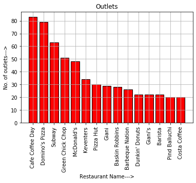

```python
import numpy as np
import pandas as pd
import operator
import matplotlib.pyplot as plt
outlet = dict()
for i in df1.index:
    key = df1['Restaurant Name'][i]
    if key in outlet:
        outlet[key] += 1
    else:
        outlet[key] = 1

outlet = dict(sorted(outlet.items(), key = operator.itemgetter(1), reverse = True))
a = 0
x = []
y = []
for i in outlet:
    if a == 15:
        break
    x.append(i)
    y.append(outlet[i])
    a += 1

plt.bar(x, y,color = "red",edgecolor="black")
plt.xticks(rotation = 90)
plt.xlabel('Restaurant Name--->')
plt.ylabel('No. of outlets--->')
plt.title('Outlets')
plt.grid()
plt.show()
```

## 2.Plot the histogram of aggregate rating of restaurant( drop the unrated restaurant).

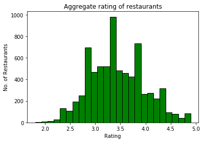

```python
x = []
for i in df1.index:
    if df1['Aggregate rating'][i] == 0:
        continue
    x.append(df1['Aggregate rating'][i])
plt.hist(x, color = "green",edgecolor="black", bins = 25)
plt.xlabel('Rating')
plt.ylabel('No. of Restaurants')
plt.title('Aggregate rating of restaurants')
plt.show()
```

## 3.Plot the bar graph top 10 restaurants in the data with the highest number of votes.

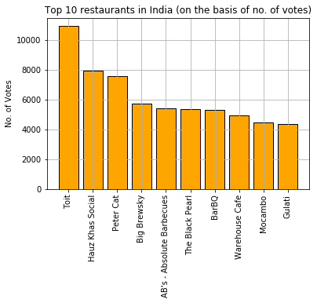

```python
votes = dict()
for i in df1.index:
    key = df1['Restaurant Name'][i]
    votes[key] = df1['Votes'][i]

votes = dict(sorted(votes.items(), key = operator.itemgetter(1), reverse = True))

x = []
y = []
a = 0
for i in votes:
    if a == 10:
        break
    x.append(i)
    y.append(votes[i])
    a += 1

plt.bar(x, y, edgecolor = "black",color="orange")
plt.xticks(rotation = 90)
plt.title('Top 10 restaurants in India (on the basis of no. of votes)')
plt.ylabel('No. of Votes')
plt.grid()
plt.show()
```

## 4.Plot the pie graph of top 10 cuisines present in restaurants in the USA.

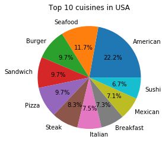

```python
df2 = df[df['Country Code'] == 216]

cuisine = dict()

for i in df2.index:
    temp = df2['Cuisines'][i]
    if type(temp) != str:
        continue
    temp = temp.split(',')
    for key in temp:
        if key.strip() in cuisine:
            cuisine[key.strip()] += 1
        else:
            cuisine[key.strip()] = 1

cuisine = dict(sorted(cuisine.items(), key = operator.itemgetter(1), reverse = True))
x = []
y = []
a = 0
for i in cuisine:
    if a == 10:
        break
    x.append(i)
    y.append(cuisine[i])
    a += 1

plt.pie(y, labels = x, autopct = "%.1f%%")
plt.title('Top 10 cuisines in USA')
plt.show()
```

## 5.Plot the bubble graph of a number of Restaurants present in the city of India and keeping the weighted restaurant rating of the city in a bubble.

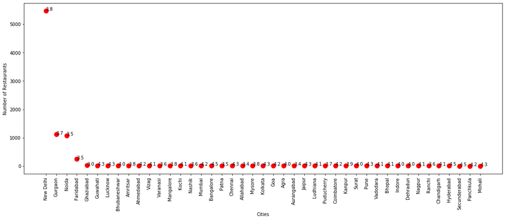

```python
import pandas as pd
import matplotlib.pyplot as plt
df=pd.read_csv('Datasets/zomato.csv',encoding='latin-1') #Dataframe for all country
df=df.copy() #Data copy
locality=[]
ef=df[df['Country Code']==1] # India country data
new=ef.City.value_counts() #city value counts
Weighted_Restaurant_Rating=[]
res_name=new.index # city name as index
no_of_res=new.values #city count as a value
for i in res_name:
    locality.append(i)
    tf=df[df.City==i]
    af=tf.copy()
    af['new_col']=tf['Votes']*tf['Aggregate rating'] #adding new column in data frame
    total=af.new_col.sum() #sum of all col data
    count=af.Votes.sum() #sum of votes
    weighted=total/count #weighted restaurant rating for each
    Weighted_Restaurant_Rating.append(weighted)
Weighted_Restaurant_Rating = [ round(elem, 1) for elem in Weighted_Restaurant_Rating]#round of the value of Weighted_Restaurant_Rating
#Plotting Graph
plt.subplots(figsize=(19,7))
plt.scatter(res_name,no_of_res,s=100,color='red')
plt.xlabel('Cities')
plt.ylabel('Number of Restaurants')
plt.xticks(rotation=90)
#pltting the value in th graph.
for i in range(len(Weighted_Restaurant_Rating)):
    plt.text(res_name[i],no_of_res[i],Weighted_Restaurant_Rating[i]) #text value in graph.
plt.show()
```